# Plague Denmark Paper

*This manuscript ([permalink](https://rawcdn.githack.com/ktmeaton/obsidian-public/7dcbba04/academic/Plague%20Denmark%20Paper.html)) was automatically generated from [ktmeaton/obsidian-public@7dcbba04](https://github.com/ktmeaton/obsidian-public/tree/7dcbba04) on July 8, 2021.*

## Authors

- **Katherine Eaton**  
  0000-0001-6862-7756 · ktmeaton  
  McMaster Ancient DNA Center; Department of Anthropology, McMaster University
- **Ravneet Sidhu**  
  McMaster Ancient DNA Center; Department of Biology, McMaster University
- **Julia Gamble**  
  0000-0001-7486-757X  
  University of Manitoba
- **Jesper Boldsen**  
  0000-0002-2850-0934  
  University of Southern Denmark; ADBOU
- **Ann Carmichael**  
  Indian University Bloomington
- **Nükhet Varlık**  
  0000-0001-6870-5945  
  University of South Carolina
- **Hendrik Poinar**  
  0000-0002-0314-4160  
  McMaster Ancient DNA Center; Department of Anthropology, McMaster University

## Abstract

### Background

The sequencing of ancient pathogen genomes has resulted in vast advancements to our understanding of the second plague pandemic. However, due to limited sample availability, debate remains about the Plague’s origins, routes of dissemination, genomic diversity, and persistence. Specifically, Scandinavia has a unique history with regards to plague persistence as it is home to the oldest known strain of plague to date and has been ravaged by historic epidemics, only for the plague to have disappeared from this region in the modern era.

### Problem

It is unknown to what extent local plague reservoirs fed the recurring epidemics in Scandinavia as compared to the continual introduction of globally circulated strains. Previously studied historical records primarily derive from large commercial centres such as London, which are contrasted by countries such as Denmark where the archives have retained limited information about the spread of the plague and its impact on society.

### Objectives

To confidently identify and sequence ancient *Yersinia pestis* from Danish archaeological sites across a wide geographic and temporal range. With the aim of performing genomic analyses to estimate the timing, spread, and evolutionary changes occurring within Danish plague strains as compared to neighboring regions.

### Significance

First, there have been relatively few studies that explore the genetics of plague in Scandinavia across time and geography, particularly in Denmark. Second, this paper contributes to a larger body of epidemiological literature that considers the patterns and mechanisms by which diseases emerge, propagate, and go extinct.

## Sites and Samples

Table 1: Summary of archaeological sites sampled in this study.

[output not shown]

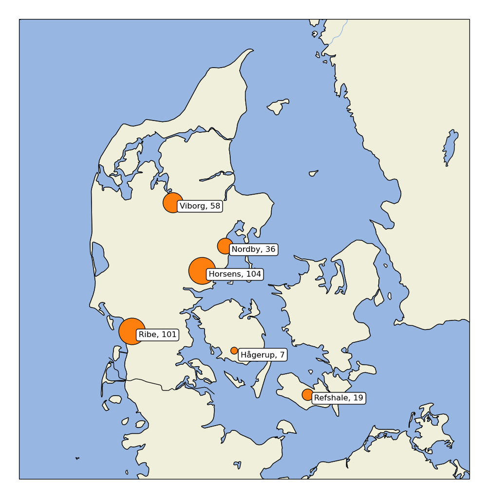

Figure 1: Geographic map of archaeological sites by region.

## Plague Detection

13 individuals were identified as plague-positive based on a combination of PCR assays, shotgun sequencing, and targeted enrichment for the *Y. pestis* whole genome (Tables 2 and 3). Of the 13 individuals, 9 had chromosomal coverage sufficient for phylogenetic analyses.

> - Absence of plague in Viking/Early Modern could easily be a false negative.
> - These periods are sparsely sampled, with fewer sites and individuals sampled.
> - Are G25A and G25B two individuals from the same grave?

Table 2: Plague positive summary of high coverage genomes.

| Arch ID | Project ID | Site | PCR | Human (%) | Plague (%) | CHROM | pCD1 | pMT1 | pPCP1 |
| --- | --- | --- | --- | --- | --- | --- | --- | --- | --- |
| G16 | D71 | Ribe Gräbrødre | 6/6 | 5.95 | 0.18 | 22.6 | 39.4 | 14.7 | 4.6 |
| G861 x1035 | D75 | Ribe Gräbrødre | 6/6 | 4.42 | 0.23 | 17.4 | 40.2 | 16.5 | 3.4 |
| G25B x98 | R36 | Ribe Gräbrødre | 6/6 | 8.41 | 0.25 | 24.0 | 51.8 | 14.9 | 5.8 |
| G25A | D62 | Ribe Gräbrødre | 6/6 | 1.12 | 0.10 | 3.8 | 10.5 | 2.5 | 0.9 |
| G207 | D72 | Ribe Gräbrødre | 6/6 | 12.94 | 0.04 | 6.0 | 13.5 | 5.8 | 2.2 |
| A146 x3011 | P187 | Sejet | 6/6 | 0.68 | 0.01 | 4.9 | 18.4 | 6.6 | 52.2 |
| G371 | P212 | Tirup | 6/6 | 0.61 | 0.04 | 6.7 | 26.3 | 8.5 | 56.6 |
| Gr GC 15 | D51 | Faldborg | 6/6 | 0.67 | 0.05 | 9.0 | 25.4 | 8.1 | 2.0 |
| A1480 x1480 | P387 | Ole Wormsgade | 6/6 | 0.04 | 0.01 | 6.5 | 21.7 | 5.0 | 75.0 |

Table 3: Plague positive summary of low coverage genomes.

| Arch ID | Project ID | Site | PCR | Human (%) | Plague (%) | CHROM | pCD1 | pMT1 | pPCP1 |
| --- | --- | --- | --- | --- | --- | --- | --- | --- | --- |
| A1155 x1155 | P384 | Ole Wormsgade | 4/6 | 0.11 | 0.01 | 1.1 | 4.8 | 1.4 | 19.6 |
| Gr ID 319 | R21 | Faldborg | 6/6 | 0.85 | 0.01 | 2.6 | 3.8 | 2.3 | 0.4 |
| A19 X21 | D24 | Hågerup | 6/6 | 0.55 | 0.01 | 2.6 | 6.1 | 1.9 | 0.7 |
| X1265 | P246 | Ribe Lindegärden | 6/6 | 0.03 | 0.01 | 0.1 | 0.1 | 0.1 | 3.2 |

## Dating

I’m relying heavily on the discussion in Boldsen (2009) [1], as quoted here:

*“The dating of individual skeletons is a fundamental problem in historical studies like this, and even the period of usage of each cemetery raises some serious problems. However, most cemeteries have at least some documentary sources broadly framing them in time. The most intensely studied skeletal samples, Tirup and Westerhus, are really the only exceptions in being dated solely on archaeological evidence (Kieffer-Olsen et al. 1986, Sivěn 2005).”*

*“In medieval graves the position of the arms in relation to the rest of the skeleton in the grave is the only feature that systematically indicates dating of the burial within the temporal frame provided by the period of usage of the cemetery. Arm position dating is primarily based on work by Redin (1976) and Kieffer-Olsen (1993). The successive stages of arm position from A (the arms besides the body) over B (hand joint over the lower part of the abdomen and usually found in the pelvis) and C (the forearms over the upper part of the abdomen and the elbows flexed in an approximately right angle) to D (the hands placed on the shoulders, forearms often crossed over the chest) have primarily been described by Kieffer-Olsen (1993) but Jantzen et al. (1994) have slightly modified the transition dates between the various stages.”*.

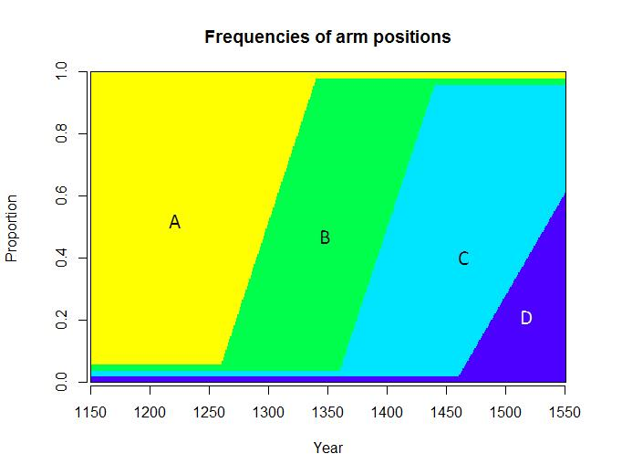

Figure 2: Arm position dating.

The skeletal and molecular dates of the 9 high coverage *Y. pestis* genomes are presented in Table 4 and Figure 4. Almost all molecular dates had overlap with the archaeological dates as determined by the site occupation period and burial patterns. The exception to this pattern was individual G371 from the site of Tirup.

Table 4: Summary of the *Y. pestis* molecular dates. The estimated tip date reflects the 95% highest posterior density.

| ID | Region | Site | Site Occupation | Arm Position | Skeletal Date | Tip Date |
| --- | --- | --- | --- | --- | --- | --- |
| G16 | Ribe | Ribe Gräbrødre | 1200 - 1560 | C | 1350 - 1550 | 1310 - 1388 |
| G861 x1035 | Ribe | Ribe Gräbrødre | 1200 - 1560 | C | 1350 - 1550 | 1489 - 1567 |
| G25B x98 | Ribe | Ribe Gräbrødre | 1200 - 1560 | C | 1350 - 1550 | 1327 - 1414 |
| G25A | Ribe | Ribe Gräbrødre | 1200 - 1560 | C | 1350 - 1550 | 1295 - 1375 |
| G207 | Ribe | Ribe Gräbrødre | 1200 - 1560 | C | 1350 - 1550 | 1477 - 1551 |
| A146 x3011 | Horsens | Sejet | 1150 - 1574 | B | 1250 - 1425 | 1397 - 1470 |
| A1480 x1480 | Horsens | Ole Wormsgade | 1100 - 1500 | ? | ? | 1384 - 1473 |
| G371 | Horsens | Tirup | 1150 - 1350 | B | 1250 - 1425 | 1419 - 1490 |
| Gr GC 15 | Viborg | Faldborg | 1100 - 1600 | C | 1350 - 1550 | 1539 - 1655 |

To investigate the dating disparity for G371, we performed 14C radiocarbon dating (Figure 3). The radiocarbon estimate largely agrees with the archaeological dates, with an estimated mean date of 1260 CE (+/- 75 yrs with 1 sigma). Thus there is robust evidence that the individual lived and died sometime between the late 12th and early 14th century

However, the associated *Y. pestis* genome is dated to the 15th century. While the 2 sigma distribution of the radiocarbon date does extends into the 15th century, there remains a substantial conflict between the date of the host and the associated pathogen.

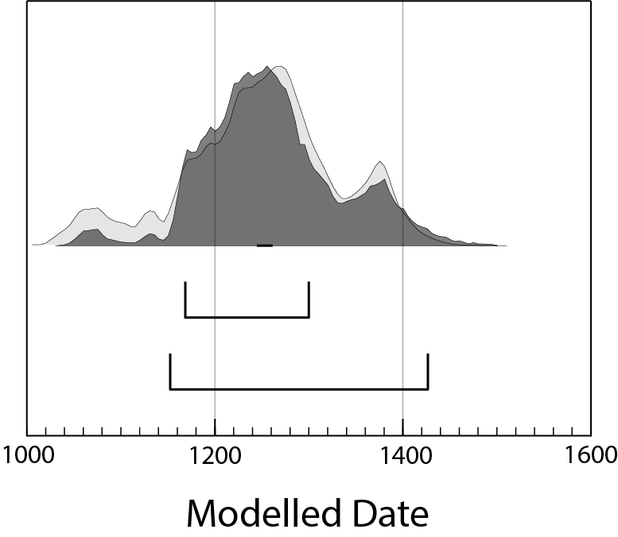

Figure 3: Radiocarbon dating of G371.

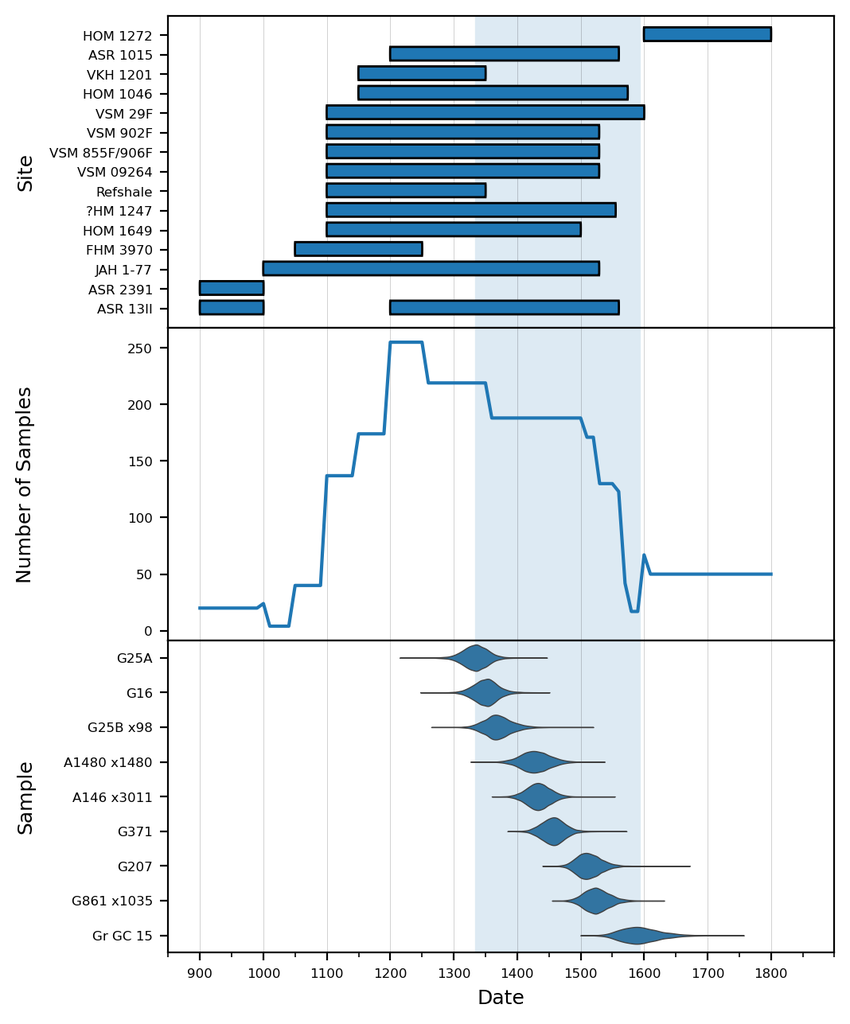

Figure 4: Timeline of archaeological sites and plague-positive individuals. The shaded range spans the highest probability period from the oldest to the youngest sample.

## Phylogeny

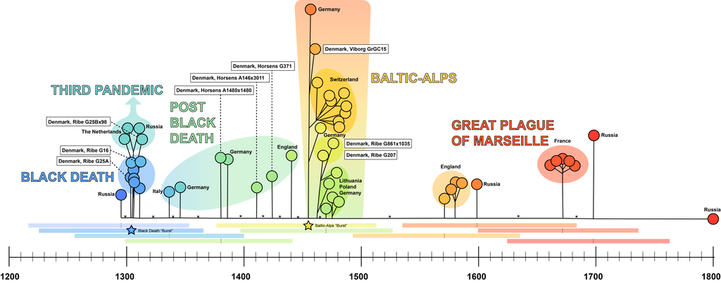

Figure 5: A timeline phylogeny of the Second Plague Pandemic. Asterisks indicate branches with strong statistical support along the main branch.

> - The traditional phylogeny layout can be found in the Appendix in Figures 6 and 7.

### The Black Death “Burst”

Two individuals from Ribe, G25A and G16, cluster with *Y. pestis* strains dated to the 14th century. This cluster is thought to be associated with the Black Death (1346-1353), as the genomes are nearly identical and have been isolated from all across Europe, including France, Spain, England, Germany, and Norway. These genomes mark the first observation of *Y. pestis* in Denmark and is congruent with historical records that document the arrival of the Black Death in Ribe in 1349 [2].

Similar to the rest of Western Europe, *Y. pestis* appears suddenly in Denmark in the 14th century. No evidence of *Y. pestis* was found in Denmark during the preceding centuries, suggesting plague was a relatively new disease for medieval Danish populations. If true, this would imply an immunologically naive population and may have important implications for the study of health and immunity in both past and present Denmark.

Unfortunately, the high degree of genetic similarity means that the branching patterns, and thus dispersal of *Y. pestis*, cannot be resolved during this period. Our understanding of the Black Death clade is that of a “Burst” radiation, with limited genetic diversity spreading rapidly over a vast geographic area. This pattern is typical of epidemic spread, and has also been observed at the advent of the Third Plague Pandemic.

### Ancestors of the Third Pandemic

Interestingly, the *Y. pestis* genome associated with individual G25Bx98 (who was found in the same grave as G25A?) is genetically distinct from the earlier strains from Ribe. This isolate falls within a clade of high epidemiological significance, which is the ancestral group giving rise to Branch 1, which includes the Third Pandemic of plague.

The phylogenetic position of samples within this clade has been hypothesized to reflect a “backward” migration of plague from Northern Europe into Asia. The *Y. pestis* genome retrieved from G25Bx98 tentatively supports this hypothesis, as it falls basal to the more derived strains from The Netherlands and Russia. However, directionality cannot be robustly inferred from four samples alone, particularly given the strong Western European sampling bias of Second Pandemic samples. It will be an important avenue of future research to further develop the relationship between Northern European plague and the only Second Pandemic lineage that is known to persist until the present.

### Post Black Death

In contrast to the genetic homogeneity observed across Europe during the Black Death period, isolates of plague in the post-Black Death period are easily distinguished. Three genomes collected from three different sites near Horsens derive from independent emergences, despite having temporal overlap. This has also been observed in Germany during this period, as samples collected in relatively close proximity are genetically distinct. This mechanism of evolution is the defining dynamic of plague during this period as all *Y. pestis* collected after the Black Death, but prior to the Early Modern Period, are unique lineages.

Again, the geographic origins and dispersal of plague during this period are challenging to reconstruct, given that the number of genomes (N=7) is sparsely sampled relative to the minimum number of countries (N=4) that are implicated. However, this broad geographic dispersal may suggest that plague outbreaks in Denmark during this period were not locally derived, but instead shared transmission with neighboring European countries.

> - Epidemiologically, I don’t know the significance of this. But I think it’s interesting!

### Early Modern Plague

Following the Medieval Period, the evolutionary dynamic of *Y. pestis* changes yet again and a second “Burst” event occurs. Similar to the Black Death “Burst”, this event begins with a series of divergences in quick succession, producing highly similar genomes in contemporaneous individuals from Germany, Lithuania, and Poland. Following these divergences, two major lineages emerge.

The first lineage, termed the Baltic-Alps, has been been previously observed in the Baltic countries (Lithuania, Poland, Germany) and the Alps (Switzerland). Three Danish genomes fall within the Baltic-Alps clade, including two samples from coastal Ribe and one sample from inland Viborg. The addition of these samples strengthens the geographic ties of this lineage to the Baltic Region. The epidemiological significance of this localization has been speculated to indicate the formation of a novel plague reservoir within Europe.

The second lineage that emerges in this period gives rise to later epidemics of plague in Russia, England, and France, including the Great Plague of Marseille (1720-1721). No Danish plague in this study is associated with this lineage. As sampling efforts intensify, it will be interesting to see if these two lineages remain geographically distinct, and to investigate what might be obstructing the flow of pathogens between them.

## References

1. **Leprosy in Medieval Denmark — Osteological and epidemiological analyses**  
Jesper L. Boldsen  
*Anthropologischer Anzeiger* (2009) http://www.jstor.org/stable/29543069

2. **The Black Death**  
Kristina Lenz, Nils Hybel  
*Scandinavian Journal of History* (2016) https://journals.scholarsportal.info/details/03468755/v41i0001/54_tbd.xml  
DOI: 10.1080/03468755.2015.1110533

## Appendix

### Phylogeny

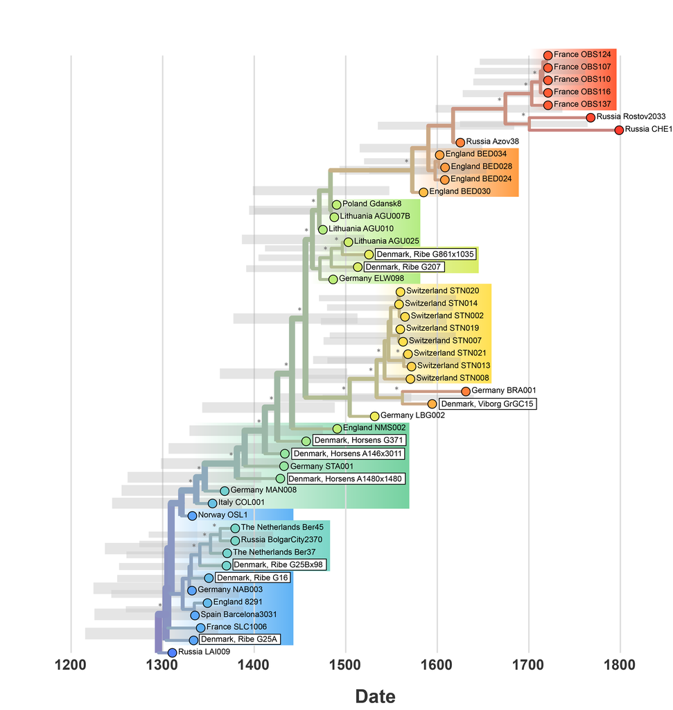

Figure 6: A time-scaled phylogeny of the Second Plague Pandemic. Asterisks indicate branches with strong statistical support.

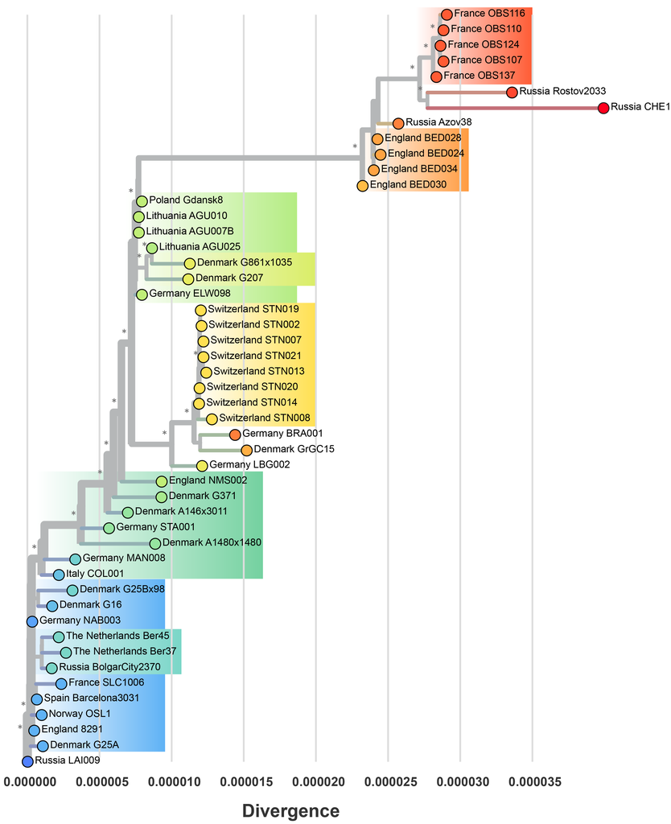

Figure 7: A divergence-scaled phylogeny of the Second Plague Pandemic. Asterisks indicate branches with strong statistical support.

### Miscellaneous

Table 5: Plague false positive summary.

| Arch ID | Project ID | Site Code | PCR | Human (%) | Plague (%) | Chrom | pCD1 | pMT1 | pPCP1 |
| --- | --- | --- | --- | --- | --- | --- | --- | --- | --- |
| G70 x212 | R44 | ASR 1015 | 3/6 | 1.48 | 0.00 | 0.1 | 0.1 | 0.1 | 0.0 |
| G860 | R39 | ASR 1015 | 5/6 | 0.09 | ? | ? | ? | ? | ? |
| G364 | R43 | ASR 1015 | 4/6 | ? | ? | ? | ? | ? | ? |
| K1167 x1167 | P235 | ASR 13 II | 3/6 | ? | ? | ? | ? | ? | ? |
| A21 x23 | D25 | ØHM 1247 | 4/6 | 0.01 | 0.00 | 0.05 | 0.1 | 0.0 | 0.0 |
| G260 K539 x876 | R27 | VSM 09264 | 3/6 | ? | ? | ? | ? | ? | ? |

### Methods

To estimate dates for the plague-positive individuals, a Bayesian Evaluation of Temporal Signal (BETS) was first performed. Briefly, each candidate model was tested using the correct collection dates of all samples and then compared to the same model with all collection dates assumed to be contemporaneous. Bayes factors (BF) were calculated by comparing the marginal likelihoods of each model, as estimated with a generalized stepping stone (GSS) computation across 100 chains each sampled over 1,000,000 generations.

The BETS analysis revealed decisive support for temporal signal (dates vs. no dates) using both the strict clock (SC) and uncorrelated lognormal relaxed clock (UCLN) (Table 6). A comparison of the strict vs. relaxed clocks using collection date produced decisive support for the relaxed clock.

Table 6: Bayesian Evaluation of Temporal Signal (BETS) summary.

| Model | Abbrev. | Dates | Likelihood | Bayes Factor (Dates) | Bayes Factor (Model) |
| --- | --- | --- | --- | --- | --- |
| Strict Clock | SC | Yes | -5948088 | 749 | – |
|  |  | No | -5948837 | – | – |
| Relaxed Clock | UCLN | Yes | **-5947948** | 715 | 140 |
|  |  | No | -5948663 | – | – |

A time-scaled phylogeny with tip-dating was estimated using a relaxed clock and diffuse normal priors centered around the mean collection date.